# Final Report

Haocheng Qin

[Click here for HTML version](https://github.com/ShimizuYukii/OtherReports/blob/main/FinalReport.html)

## Introduction

The dataset under analysis comprises standardized educational assessment results (Washington Assessment of Student Learning, WASL) and school-level demographic information from the state of Washington during the 2005-2006 school year. WASL was administered to students in public schools across Washington to evaluate proficiency in reading, writing, mathematics, and science. This dataset consists of following variables:

- County - the county in which the school is located.
- School - the school reporting the results.
- GradeTested - the grade of the tested students.
- Math/Reading/Writing/ScienceMetStandard - the number of students meeting the WASL standard to the related section.
- Math/Reading/Writing/ScienceTotalTested - the total number of students tested in related WASL section.
- TotalEnrollment - the number of students in all grades of the school.
- PercentWhite - the percentage of White students in the school.
- StudentsPerClassroomTeacher - the number of students per classroom teacher.
- FreeorReducedPricedMeals - the percentage of students eligible for free or reduced-price meals.
- AvgYearsEducationalExperience - average years of educational experience of teachers employed in the school.
- PercentTeachersWithAtLeastMasterDegree - the percentage of teachers with master’s degree or higher employed in the school.

For this analysis, the primary focus is (1) the relationship between school resource variables and (2) identify over-performing and under-performing schools after accounting for demographic characteristics.

## Study Design

This data is made of 1481 records of 1362 schools in WASL testing, each line includes performance outcomes for different sections (Math, Reading, Writing and Science) and demographic characteristics. In this study, we focus on the variables in the way of:

- Target Outcome Variables: Pass rates for Math/Reading/Writing/Science, difined as
  $$PassRate=\frac{Math/Reading/Writing/ScienceMetStandard}{Math/Reading/Writing/ScienceTotalTested}$$
- Macro Explanatory Variables: All demographic characteristics, i.e. County, TotalEnrollment, PercentWhite, StudentsPerClassroomTeacher, FreeorReducedPricedMeals, AvgYearsEducationalExperience and PercentTeachersWithAtLeastMasterDegree.
- Micro Explanatory Variables: GradeTested and the Section related to the PassRate

This design is based on the natural assumption that demographic characteristics influence different sections in a similar manner. For instance, if a larger classroom size benefits learning in Reading, it would logically also benefit learning in Math. However, the difficulty level of different subjects varies, resulting in an overall inconsistency in Pass Rates, but the impact of demographic characteristics remains consistent.

The aim of this design is to explore the various factors that affect students’ Pass Rates. Instead of discussing the problem on a subject-by-subject basis, we aim to study the overall impact of demographic characteristics on student learning. This design also facilitates identifying over-performing and under-performing schools for further analysis. With this purpose in mind, we consider using hierarchical modeling, such as ANOVA or LME (Linear Mixed-Effects Models), to examine the effects of fixed and random factors. The goal is to find an appropriate model that explains the significance and impact of various variables.

Of course, the data is at the school level, so individual student variability is not accounted for. Additionally, approximately 300 small schools are excluded due to missing WASL results, potentially introducing selection bias. However, overall, this dataset is representative and informative for guiding school-level decisions.

## Data Description

### Data Processing

Firstly we have to process the data as following:

- Since it’s hard to analyze multiple target variables, we have to compute the PassRate of each Section, the pivot the result into two columns PassRate and related Section, then the target of interest will be just the PassRate.
- We renamed some variables for convinience. Actually N = TotalEnrollment, ClassSize = StudentsPerClassroomTeacher, PercentFree = FreeorReducedPricedMeals, AvgEduYears = AvgYearsEducationalExperience and PercentMaster = PercentTeachersWithAtLeastMasterDegree.

After both, the dataset becomes like (has been split into two tables due to the page size, while actually a whole one):

| PassRate | School | County | Section | GradeTested | N |
| --- | --- | --- | --- | --- | --- |
| 0.2343750 | Lutacaga Elementary | Adams | Math | 5 | 626 |
| 0.5000000 | Lutacaga Elementary | Adams | Reading | 5 | 626 |
| 0.0428571 | Lutacaga Elementary | Adams | Science | 5 | 626 |
| 0.3108108 | Hiawatha Elementary School | Adams | Math | 5 | 621 |
| 0.5466667 | Hiawatha Elementary School | Adams | Reading | 5 | 621 |

| PassRate | PercentWhite | ClassSize | PercentFree | AvgEduYears | PercentMaster |
| --- | --- | --- | --- | --- | --- |
| 0.2343750 | 13.8978 | 16 | 78.7829 | 6.8 | 33.3 |
| 0.5000000 | 13.8978 | 16 | 78.7829 | 6.8 | 33.3 |
| 0.0428571 | 13.8978 | 16 | 78.7829 | 6.8 | 33.3 |
| 0.3108108 | 17.7134 | 19 | 84.5140 | 11.8 | 51.5 |
| 0.5466667 | 17.7134 | 19 | 84.5140 | 11.8 | 51.5 |

- Notice there are some missing values, and we simply delete them since the dataset is large enough.
- After exploring each demographic characteristic variable (as the figure following shows), we find there are slight linear patterns in variables like N, PercentWhite and PercentFree, but not that obvious.
- Also we find there are some truncations on the variables, like PercentWhite and PercentFree and PassRate, to cancel this we deleted observations on the boundary.

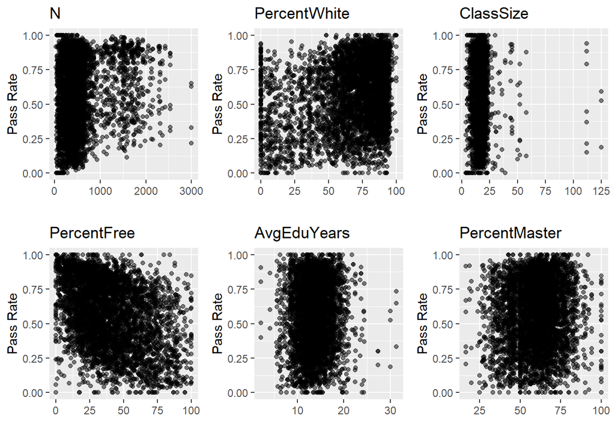

### Data Heterogeneity

In this section we are exploring main sources of heterogeneity in the dataset besides demographic variables.

- For the following plot of PassRate vs County for each Section, we can conclude
- County accounts for the heterogeneity of the data, we can obviously see the differences.
- The trend for each Section is similar, which means, if one county (similar to schools) has better performance in one section, it will likely have a better performance in another section.

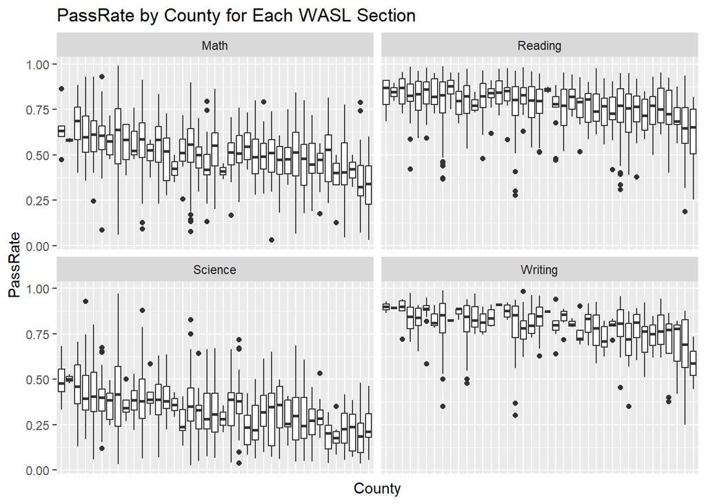

- For the following plot of PassRate distributions for each Section, we can conclude
- Sections accounts for the heterogeneity of the data, of course, since the difficulties are different.
- The PassRate for Math and Science are normal, while for Reading and Writing are skewed. But we may assume that they are all generally normal.

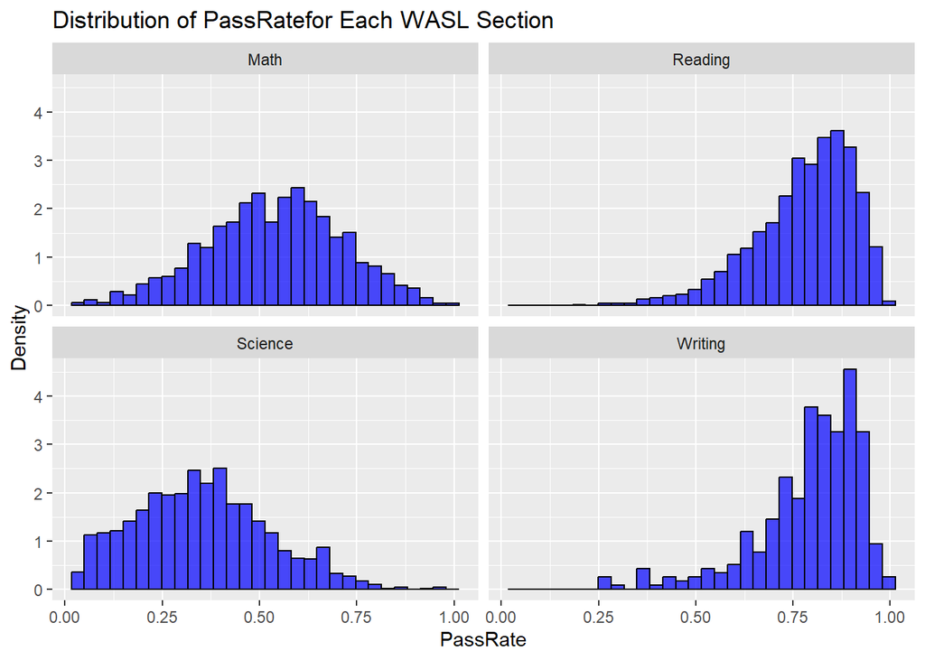

- For the grade tested, we perform an anova over it, and it dose account for the heterogeneity since the pavlue is significant.

```
## Analysis of Variance Table
##
## Response: PassRate
##               Df  Sum Sq Mean Sq F value    Pr(>F)
## GradeTested    1   3.021 3.02068  53.878 2.528e-13 ***
## Residuals   4397 246.519 0.05607
## ---
## Signif. codes:  0 '***' 0.001 '**' 0.01 '*' 0.05 '.' 0.1 ' ' 1
```

## Model Fitting and Diagnostics

### Model 1: Normal Linear Model

Firstly let’s consider the basic linear model. For convenient, we just include all demographic characters in $\boldsymbol{X}_{demographic}$ and all related linear coefficients in $\boldsymbol{\beta}_{2j}$. Then the model is like:

$$y_{ij}=\beta_0+\beta_{1j}X_{section}+\boldsymbol{X}_{demographic}\boldsymbol{\beta}_{2j}+\varepsilon_{ij}\tag{model-lm-1}$$

where the assumptions are regular that $\varepsilon_{ij}\stackrel{i.i.d.}{\sim} N(0,\sigma^2)$.

```
##
## Call:
## lm(formula = PassRate ~ Section + GradeTested + N + PercentWhite +
##     ClassSize + PercentFree + AvgEduYears + PercentMaster, data = data)
##
## Residuals:
##      Min       1Q   Median       3Q      Max
## -0.54285 -0.07624  0.00189  0.07260  0.57833
##
## Coefficients:
##                  Estimate Std. Error t value Pr(>|t|)
## (Intercept)     6.856e-01  1.800e-02  38.088  < 2e-16 ***
## SectionReading  2.415e-01  4.805e-03  50.271  < 2e-16 ***
## SectionScience -1.859e-01  4.806e-03 -38.689  < 2e-16 ***
## SectionWriting  2.628e-01  8.197e-03  32.063  < 2e-16 ***
## GradeTested10  -5.099e-02  5.038e-03 -10.122  < 2e-16 ***
## N               3.782e-05  5.407e-06   6.994 3.08e-12 ***
## PercentWhite    6.726e-04  1.154e-04   5.826 6.09e-09 ***
## ClassSize      -3.718e-03  5.633e-04  -6.601 4.58e-11 ***
## PercentFree    -3.880e-03  1.161e-04 -33.433  < 2e-16 ***
## AvgEduYears     3.212e-04  6.603e-04   0.486    0.627
## PercentMaster   2.056e-04  1.501e-04   1.370    0.171
## ---
## Signif. codes:  0 '***' 0.001 '**' 0.01 '*' 0.05 '.' 0.1 ' ' 1
##
## Residual standard error: 0.1249 on 4388 degrees of freedom
## Multiple R-squared:  0.7255, Adjusted R-squared:  0.7249
## F-statistic:  1160 on 10 and 4388 DF,  p-value: < 2.2e-16
```

Notices that not all variables are significant. AvgEduYears and PercentMaster are not significant here, which is consistent to the sections above. So we consider fit another model with only the significant varibles $\boldsymbol{X}_{demographic}^*$ (actually $\boldsymbol{X}_{demographic}^*=(X_{gradetested},X_N,X_{PercentWhite},X_{ClassSize},X_{PercentFree})$), then we fit:

$$y_{ij}=\beta_0+\beta_{1j}X_{section}+\boldsymbol{X}^*_{demographic}\boldsymbol{\beta}_{2j}+\varepsilon_{ij}\tag{model-lm-2}$$

and since by BIC:

```
##            df       BIC
## model_lm_1 12 -5725.796
## model_lm_2 10 -5740.295
```

model_lm_2 would be better.

### Model Diagnostics

So we now do diagnostics on model-lm-2

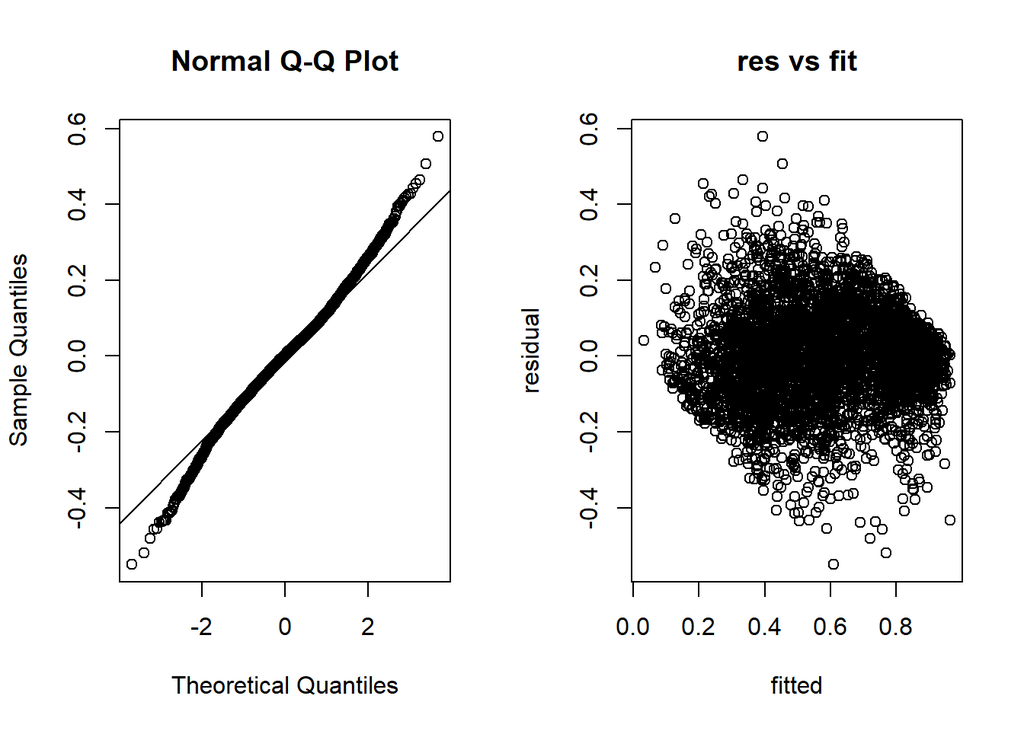

```
## Analysis of Variance Table
##
## Response: abs(model_lm_2$residuals)
##                Df  Sum Sq Mean Sq  F value    Pr(>F)
## Section         3  0.8201 0.27337  45.4709 < 2.2e-16 ***
## GradeTested     1  0.0098 0.00979   1.6285  0.201975
## N               1  1.1735 1.17346 195.1887 < 2.2e-16 ***
## PercentWhite    1  0.0466 0.04659   7.7498  0.005395 **
## ClassSize       1  0.0036 0.00358   0.5954  0.440380
## PercentFree     1  0.0451 0.04513   7.5060  0.006174 **
## Residuals    4390 26.3924 0.00601
## ---
## Signif. codes:  0 '***' 0.001 '**' 0.01 '*' 0.05 '.' 0.1 ' ' 1
```

### Model 2: Generalized Linear Model

We want to try other GLMs since the data is not actually strictly normal, for example, we may want to perform gamma regression as:

$$\log(y_{ij})=\beta_0+\beta_{1j}X_{section}+\boldsymbol{X}_{demographic}\boldsymbol{\beta}_{2j}+\varepsilon_{ij}\tag{model-glm}$$

```
##
## Call:
## glm(formula = PassRate ~ Section + GradeTested + N + PercentWhite +
##     ClassSize + PercentFree + AvgEduYears + PercentMaster, family = Gamma(link = "log"),
##     data = data)
##
## Coefficients:
##                  Estimate Std. Error t value Pr(>|t|)
## (Intercept)    -3.753e-01  4.315e-02  -8.698  < 2e-16 ***
## SectionReading  3.962e-01  1.152e-02  34.404  < 2e-16 ***
## SectionScience -4.440e-01  1.152e-02 -38.541  < 2e-16 ***
## SectionWriting  4.355e-01  1.965e-02  22.166  < 2e-16 ***
## GradeTested10  -1.162e-01  1.208e-02  -9.619  < 2e-16 ***
## N               6.668e-05  1.296e-05   5.144 2.80e-07 ***
## PercentWhite    1.978e-03  2.767e-04   7.148 1.03e-12 ***
## ClassSize      -8.736e-03  1.350e-03  -6.470 1.09e-10 ***
## PercentFree    -8.023e-03  2.782e-04 -28.839  < 2e-16 ***
## AvgEduYears     1.409e-03  1.583e-03   0.890   0.3736
## PercentMaster   6.521e-04  3.597e-04   1.813   0.0699 .
## ---
## Signif. codes:  0 '***' 0.001 '**' 0.01 '*' 0.05 '.' 0.1 ' ' 1
##
## (Dispersion parameter for Gamma family taken to be 0.08969314)
##
##     Null deviance: 1109.70  on 4398  degrees of freedom
## Residual deviance:  472.57  on 4388  degrees of freedom
## AIC: -3208
##
## Number of Fisher Scoring iterations: 5
```

```
## [1] -3131.301
```

We can see the BIC is too large comparing to models above, so we will not waste our time in variables selection here.

### Model 3: Linear Mixed Model

In this section, we will explore linear mixed effect models with random effects School and County. It is intuitive based on our data exploration above, that is, School and County accounts for some heterogeneity as group factors.

We will test the full model first, which is

$$y_{ij}=\beta_0+\beta_{1j}X_{section}+\boldsymbol{X}_{demographic}\boldsymbol{\beta}_{2j}+\alpha_{County,j}+\alpha_{School,j}+\varepsilon_{ij}\tag{model-lme-1}$$

where the assumptions are regular that $\varepsilon_{ij}\stackrel{i.i.d.}{\sim} N(0,\sigma^2),\alpha_{County,j}{\sim} N(0,\tau_{1}^2),\alpha_{School,j}{\sim} N(0,\tau_2^2)$.

```
## Linear mixed model fit by REML ['lmerMod']
## Formula: PassRate ~ Section + GradeTested + N + PercentWhite + ClassSize +
##     PercentFree + AvgEduYears + PercentMaster + (1 | School) +
##     (1 | County)
##    Data: data
##
## REML criterion at convergence: -6775.5
##
## Scaled residuals:
##     Min      1Q  Median      3Q     Max
## -3.7219 -0.5389 -0.0014  0.5372  3.9698
##
## Random effects:
##  Groups   Name        Variance Std.Dev.
##  School   (Intercept) 0.006765 0.08225
##  County   (Intercept) 0.001626 0.04033
##  Residual             0.008206 0.09059
## Number of obs: 4399, groups:  School, 1266; County, 39
##
## Fixed effects:
##                  Estimate Std. Error t value
## (Intercept)     6.863e-01  3.100e-02  22.137
## SectionReading  2.443e-01  3.489e-03  70.027
## SectionScience -1.881e-01  3.488e-03 -53.926
## SectionWriting  2.688e-01  5.966e-03  45.050
## GradeTested10  -4.986e-02  6.859e-03  -7.270
## N               4.064e-05  8.133e-06   4.997
## PercentWhite    5.817e-04  1.963e-04   2.964
## ClassSize      -3.308e-03  8.569e-04  -3.861
## PercentFree    -3.905e-03  1.976e-04 -19.764
## AvgEduYears     8.976e-04  9.765e-04   0.919
## PercentMaster   7.744e-05  2.223e-04   0.348
##
## Correlation of Fixed Effects:
##             (Intr) SctnRd SctnSc SctnWr GrdT10 N      PrcntW ClssSz PrcntF
## SectionRdng -0.055
## SectionScnc -0.056  0.495
## SectinWrtng -0.020  0.292  0.286
## GradeTstd10 -0.038  0.000  0.006 -0.201
## N           -0.046 -0.001 -0.005  0.005 -0.439
## PercentWhit -0.575  0.002 -0.003  0.002 -0.018  0.107
## ClassSize   -0.421 -0.002  0.003  0.003  0.073 -0.349  0.035
## PercentFree -0.665 -0.002 -0.002 -0.004  0.051  0.152  0.711  0.096
## AvgEduYears -0.334 -0.001  0.001 -0.002 -0.038  0.089 -0.143 -0.026 -0.020
## PercentMstr -0.317  0.001  0.002 -0.004 -0.016 -0.048 -0.108 -0.022 -0.001
##             AvgEdY
## SectionRdng
## SectionScnc
## SectinWrtng
## GradeTstd10
## N
## PercentWhit
## ClassSize
## PercentFree
## AvgEduYears
## PercentMstr -0.107
```

### Model Comparison

Recall that we now have models as:

$$\begin{aligned}
\text{model-lm-1:}&&y_{ij}=\beta_0+\beta_{1j}X_{section}+\boldsymbol{X}_{demographic}\boldsymbol{\beta}_{2j}+\varepsilon_{ij}\\
\text{model-lm-2:}&&y_{ij}=\beta_0+\beta_{1j}X_{section}+\boldsymbol{X}^*_{demographic}\boldsymbol{\beta}_{2j}+\varepsilon_{ij}\\
\text{model-lm-3:}&&y_{ij}=\beta_0+\beta_{1j}X_{section}+\boldsymbol{X}^H_{demographic}\boldsymbol{\beta}_{2j}+\varepsilon_{ij}\\
\text{model-glm:}&&\log(y_{ij})=\beta_0+\beta_{1j}X_{section}+\boldsymbol{X}_{demographic}\boldsymbol{\beta}_{2j}+\varepsilon_{ij}\\
\text{model-lme-1:}&&y_{ij}=\beta_0+\beta_{1j}X_{section}+\boldsymbol{X}_{demographic}\boldsymbol{\beta}_{2j}+\alpha_{County,j}+\alpha_{School,j}+\varepsilon_{ij}\\
\text{model-lme-2:}&&y_{ij}=\beta_0+\beta_{1j}X_{section}+\boldsymbol{X}^{**}_{demographic}\boldsymbol{\beta}_{2j}+\alpha_{County,j}+\alpha_{School,j}+\varepsilon_{ij}\\
\text{model-lme-3:}&&y_{ij}=\beta_0+\beta_{1j}X_{section}+\boldsymbol{X^{*}}_{demographic}\boldsymbol{\beta}_{2j}+\alpha_{County,j}+\alpha_{School,j}+\varepsilon_{ij}\\
\text{model-lme-4:}&&y_{ij}=\beta_0+\beta_{1j}X_{section}+\boldsymbol{X}^H_{demographic}\boldsymbol{\beta}_{2j}+\alpha_{County,j}+\alpha_{School,j}+\varepsilon_{ij}
\end{aligned}$$

Then compare them by BIC

```
##             df       BIC
## model_lm_1  12 -5725.796
## model_lm_2  10 -5740.295
## model_lm_3   8 -5626.113
## model_glm   12 -3131.301
## model_lme_1 14 -6658.023
## model_lme_2 10 -6373.902
## model_lme_3 12 -6700.778
## model_lme_4 10 -6677.329
```

We found that model-lme-3, which is the LME model with School and County as random effects, GradeTested, N, PercentWhite, ClassSize and PercentFree as fixed effects, is the best.

## Model and Data Analysis Interpretation

Recall the coefficents of model-lme-3

```
## Linear mixed model fit by REML ['lmerMod']
## Formula: PassRate ~ Section + GradeTested + N + PercentWhite + ClassSize +
##     PercentFree + (1 | School) + (1 | County)
##    Data: data
##
## REML criterion at convergence: -6801.4
##
## Scaled residuals:
##     Min      1Q  Median      3Q     Max
## -3.7259 -0.5419  0.0000  0.5418  3.9621
##
## Random effects:
##  Groups   Name        Variance Std.Dev.
##  School   (Intercept) 0.006754 0.08218
##  County   (Intercept) 0.001637 0.04046
##  Residual             0.008206 0.09059
## Number of obs: 4399, groups:  School, 1266; County, 39
##
## Fixed effects:
##                  Estimate Std. Error t value
## (Intercept)     7.008e-01  2.706e-02  25.897
## SectionReading  2.443e-01  3.489e-03  70.025
## SectionScience -1.881e-01  3.488e-03 -53.926
## SectionWriting  2.688e-01  5.967e-03  45.052
## GradeTested10  -4.958e-02  6.849e-03  -7.239
## N               4.013e-05  8.091e-06   4.960
## PercentWhite    6.183e-04  1.926e-04   3.210
## ClassSize      -3.277e-03  8.559e-04  -3.829
## PercentFree    -3.901e-03  1.975e-04 -19.757
##
## Correlation of Fixed Effects:
##             (Intr) SctnRd SctnSc SctnWr GrdT10 N      PrcntW ClssSz
## SectionRdng -0.063
## SectionScnc -0.063  0.495
## SectinWrtng -0.026  0.292  0.286
## GradeTstd10 -0.067  0.000  0.006 -0.201
## N           -0.034 -0.001 -0.005  0.005 -0.439
## PercentWhit -0.778  0.002 -0.002  0.001 -0.026  0.118
## ClassSize   -0.502 -0.002  0.003  0.002  0.072 -0.349  0.029
## PercentFree -0.771 -0.002 -0.002 -0.004  0.051  0.155  0.721  0.095
```

### Fixed Effects

- **Section**: The interception of different sections indicates that, when it comes to the difficulty (of passing the test), Science > Math > Reading > Writing, which means WASL focus more on research skills other than expression and communication skills.
- **GradeTested**: The negative interception (-4.958e-02) means that, the tenth grade has a lower pass rate than the fifth grade, indicating that for higher grade, the WASL test will be significantly more difficult.
- **N (TotalEnrollment)**: It has a minor but statistically significant positive effect (4.013e-05). This indicates that the larger the school size, the better the average student performance, which aligns with intuition. Larger schools often mean well-equipped facilities and more established management models, which are more conducive to student learning.
- **PercentWhite**: The positive coefficient (6.183e-04) indicates that as the proportion of White students in a school increases, the pass rate also rises. This suggests racial inequality in the allocation of educational resources, with resources being skewed towards schools with predominantly White students. Another possible explanation is that White students may perform better on this type of test, as the WASL does not cover comprehensive subjects like sports.
- **ClassSize (StudentsPerClassroomTeacher)**: Firstly, a larger ClassSize means that each student has access to fewer educational resources, as each teacher is assigned to more students. The negative coefficient (-3.277e-03) indicates that as class size increases, teachers are less able to provide individual attention to each student, which naturally results in a lower average pass rate.
- **PercentFree (FreeorReducedPricedMeals)**: In fact, this feature indirectly reflects the students’ economic status. More students eligible for free or reduced-price meals indicate that the economic conditions of the student group are relatively lower. In this model, the negative coefficient (-3.901e-03) suggests that the lower the students’ economic level, the lower the pass rate. This is because families may not be able to provide a stable learning environment or additional educational resources, such as private tutors, for the students.

### Random Effects

- **School**: There is moderate variability (std = 0.08218) in the pass rates between schools, even after accounting for fixed effects. This indicates that 1. different schools do account for heterogeneity in pas rate 2. there are still unmeasured school-level factors (e.g., leadership, specific policies, or teaching strategies) influence pass rates.
- **County**: There is smaller variability (std = 0.04046) in pass rates across counties compared to schools. This suggests that, while county-level factors (e.g., funding policies, regional initiatives) may influence performance, their impact is less pronounced than school-specific factors.
- **Residual**: Residual variance (std = 0.09059 ) represents the variability in pass rates within schools that is not explained by the fixed or random effects. The relatively large residual variance indicates that still some variability not captured by the model.

### Variables not Included

Unexpectedly, the two indicators measuring the overall quality of teachers (AvgEduYears = AvgYearsEducationalExperience and PercentMaster = PercentTeachersWithAtLeastMasterDegree) are not very significant. This suggests that students’ pass rates are more closely related to their own characteristics and social conditions, with teachers playing a relatively limited supportive role.

### School Performance

We evaluate a school’s performance by the difference between its actual pass rate and the predicted pass rate from the model (in mean values). The higher this difference, the more the school exceeds expectations (over-performing), and vice versa. In other words, we use the residuals from model_lme_3 to measure school performance. The results are as follows (only the most over-performing and under-performing schools/counties are shown):

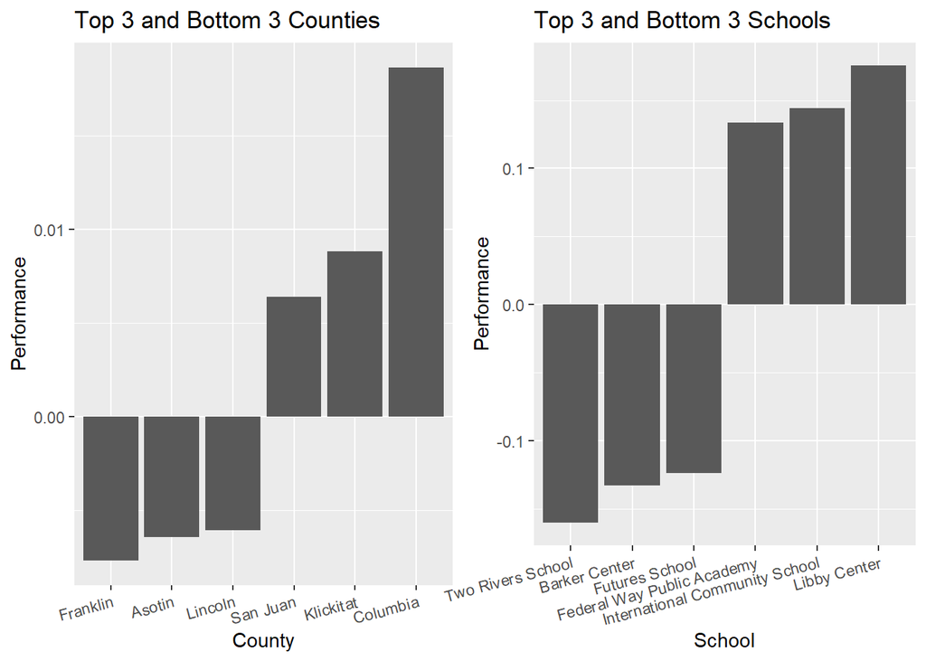

Based on performance, the top three over-performing schools are Libby Center, International Community School, and Federal Way Public Academy, while the three most under-performing schools are Futures School, Barker Center, and Two Rivers School. Of course, using the same method, we can also measure the performance differences between counties.

## Conclusions

This analysis of WASL pass rates across schools in Washington during the 2005-2006 school year has provided several critical insights into the factors influencing student performance. Demographic characteristics emerged as significant predictors of pass rates, with schools having higher proportions of White students achieving better outcomes. This finding highlights potential inequities in educational resource allocation or test design biases. Additionally, larger class sizes negatively impacted pass rates, likely due to the challenges of providing individualized attention in crowded classrooms. Schools with a higher percentage of students eligible for free or reduced-price meals also exhibited lower pass rates, underscoring the socioeconomic challenges that many students face in accessing quality education. Subject and grade-level differences were evident, with Science being the most challenging subject and Writing the least, while tenth-grade students generally faced greater difficulty compared to fifth graders.

The linear mixed-effects model (LME), incorporating school and county as random effects alongside significant fixed effects, was selected as the best-fit model for the data based on the Bayesian Information Criterion (BIC). The model identified total enrollment, racial composition, and socioeconomic indicators as strong predictors of pass rate variations, while teacher experience and qualifications showed limited impact. These findings were supported by hypothesis tests that confirmed the statistical significance of the demographic and structural variables. Residual analysis further highlighted specific schools that exceeded or fell short of expectations. These insights offer valuable benchmarks for evaluating school performance. This analysis provides a foundational understanding of the factors influencing WASL pass rates, offering valuable insights for policymakers and educators aiming to improve educational outcomes and address systemic inequities.

Despite these insights, several limitations must be acknowledged. The dataset is aggregated at the school level, failing to capture individual student variability. Furthermore, our model doesn’t hold the assumptions strictly though generally acceptable due to the skewed pattern of the pass rate. And transforming it is challenging because if the transformations differ across sections, it would result in inconsistent effects of other variables on them, which conflicts with our assumptions. Future research could address these limitations by incorporating individual-level data, exploring better alternating models.

## Replication Code

```r
# Data Processing
data.raw=read.csv('wasl.csv')
for(subject in c('Math','Reading','Writing','Science')){
  data.raw[[subject]]=data.raw[[paste0(subject,'MetStandard')]]/
    data.raw[[paste0(subject,'TotalTested')]]
}
data <- (data.raw |>
  pivot_longer(
    cols = c("Math", "Reading", "Writing", "Science"),
    names_to = "Section",
    values_to = "PassRate"
  ) |>
  filter(!is.na(PassRate)) |>
  # Select the desired columns
  select(PassRate, School,County, Section,
         GradeTested,
         N=TotalEnrollment, PercentWhite,
         ClassSize=StudentsPerClassroomTeacher,
         PercentFree=FreeorReducedPricedMeals,
         AvgEduYears=AvgYearsEducationalExperience,
         PercentMaster=PercentTeachersWithAtLeastMasterDegree)|>
    mutate(County=as.factor(County),
         GradeTested=as.factor(GradeTested) )|>
  na.omit())
kable(head(data,5))
# Cancel Truncation
data=data[data$PercentWhite!=0,]
data=data[data$PercentFree!=0,]
data=data[data$PassRate!=0,]
data=data[data$PassRate!=1,]

# Data Visualization
# Boxplot
data |>
  group_by(Section, County) |>
  summarize(MeanPassRate = mean(PassRate, na.rm = TRUE), .groups = 'drop') |>
  arrange(Section, desc(MeanPassRate)) |>
  mutate(County = factor(County, levels = unique(County))) |>
  right_join(data, by = c("Section", "County")) |>
  ggplot(aes(x = reorder(County, -MeanPassRate), y = PassRate)) +
  geom_boxplot() +
    theme(axis.text.x = element_blank(),
        axis.ticks.x = element_blank()) +
  facet_wrap(~ Section, nrow = 2, ncol = 2) +
  labs(title = "PassRate by County for Each WASL Section",
       x = "County", y = "PassRate")
# Distribution
data |>
  group_by(Section, County) |>
  summarize(MeanPassRate = mean(PassRate, na.rm = TRUE), .groups = 'drop') |>
  arrange(Section, desc(MeanPassRate)) |>
  mutate(County = factor(County, levels = unique(County))) |>
  right_join(data, by = c("Section", "County")) |>
  ggplot(aes(x = PassRate, y = after_stat(density))) +
  geom_histogram(color = "black", fill = "blue", alpha = 0.7, bins = 30) +
  facet_wrap(~ Section, nrow = 2, ncol = 2) +
  labs(title = "Distribution of PassRatefor Each WASL Section",
       x = "PassRate", y = "Density")
# Variables (run before canceling truncation)
plots=list()
vars <- colnames(data)[6:11]
for (var in vars) {
  p <- ggplot(data, aes_string(x = var, y = "PassRate")) +
    geom_point(alpha = 0.2) +
    labs(x = "", y = "Pass Rate", title = paste(var))
  plots[[var]] <- p
}
grid.arrange(grobs = plots, nrow = 2, ncol = 3)

# Model Fitting
model_lm_1 <- lm(PassRate~Section+GradeTested+N+PercentWhite+ClassSize+
                   PercentFree+
                   AvgEduYears+PercentMaster,data=data)
summary(model_lm_1)
model_lm_2 <- lm(PassRate~Section+GradeTested+N+PercentWhite+ClassSize+
                   PercentFree,data=data)

model_glm <- glm(PassRate~Section+GradeTested+N+PercentWhite+ClassSize+
                   PercentFree+
                   AvgEduYears+PercentMaster,family = Gamma(link = "log"),
                 data=data)
summary(model_glm)

model_lme_1 <- lmer(PassRate~Section+GradeTested+N+PercentWhite+ClassSize+
                      PercentFree+AvgEduYears+PercentMaster+(1|School)+
                      (1|County),data=data)
model_lme_2 <- lmer(PassRate~Section+N+PercentWhite+AvgEduYears+(1|School)+
                      (1|County),data=data)
summary(model_lme_1)
model_lme_3 <- lmer(PassRate~Section+GradeTested+N+PercentWhite+ClassSize+
                      PercentFree+(1|School)+(1|County),data=data)
model_lme_4 <- lmer(PassRate~Section+N+PercentWhite+PercentFree+(1|School)+
                      (1|County),data=data)

# Comparison and Diagnostics
BIC(model_lm_1,model_lm_2,model_lm_3,model_glm,model_lme_1,model_lme_2,
    model_lme_3,model_lme_4)

model_lm_2 <- lm(PassRate~Section+GradeTested+N+PercentWhite+ClassSize+
                   PercentFree,data=data)
par(mfrow=c(1,2))
qqnorm(model_lm_2$res)
qqline(model_lm_2$res)

plot(model_lm_2$fitted.values,model_lm_2$res,xlab = 'fitted',ylab = 'residual',
     main = 'res vs fit')

anova(lm(abs(model_lm_2$residuals)~Section+GradeTested+N+PercentWhite
         +ClassSize+PercentFree,data=data))

# Model and Data Analysis Interpretation
summary(model_lme_3)

perf=residuals(model_lme_3)
performance_data =data.frame(county=data$County,school=data$School,
                             section=data$Section,performance = perf)
school_perf = (performance_data |> group_by(school) |>
                 summarise(performance=mean(performance)) |>
                 arrange(-performance) |> slice(c(1:3, (n() - 2):n())))
county_perf = (performance_data |> group_by(county) |>
                 summarise(performance=mean(performance)) |>
                 arrange(-performance) |> slice(c(1:3, (n() - 2):n())))
perfs = list()
perfs[[2]] <- ggplot(school_perf, aes(x = reorder(school, performance),
                                      y = performance)) +
  geom_bar(stat = "identity") +
  labs(title = "Top 3 and Bottom 3 Schools",
       x = "School",
       y = "Performance") +
  theme(legend.position = "none",                # Remove legend
        axis.text.x = element_text(angle = 15,  # Rotate x-axis labels
                                   hjust = 1))
perfs[[1]] <- ggplot(county_perf, aes(x = reorder(county, performance),
                                      y = performance)) +
  geom_bar(stat = "identity") +
  labs(title = "Top 3 and Bottom 3 Counties",
       x = "County",
       y = "Performance") +
  theme(legend.position = "none",                # Remove legend
        axis.text.x = element_text(angle = 15,  # Rotate x-axis labels
                                   hjust = 1))
grid.arrange(grobs = perfs, nrow = 1, ncol = 2)
```